# Offsite Trial Reporting

### Temperature

#### Frost burns.subhygric

| Date | Day_of_Year | Duration | Magnitude |
| --- | --- | --- | --- |
| 2014-05-27 4:00 | 147 | 1 | 0.3 |
| 2014-05-28 0:00 | 148 | 7 | 4 |
| 2014-05-29 1:00 | 149 | 6 | 1.8 |
| 2014-05-30 2:00 | 150 | 5 | 3.2 |
| 2014-05-31 4:00 | 151 | 1 | 0.6 |
| 2014-06-01 0:00 | 152 | 7 | 3.6 |
| 2014-06-02 2:00 | 153 | 5 | 1.8 |
| 2014-06-03 2:00 | 154 | 5 | 2.4 |
| 2014-06-04 1:00 | 155 | 5 | 3.9 |
| 2014-06-04 23:00 | 155 | 2 | 0.6 |
| 2014-06-06 1:00 | 157 | 7 | 4.8 |
| 2014-06-07 0:00 | 158 | 6 | 3 |
| 2014-06-09 0:00 | 160 | 1 | 1.8 |
| 2014-06-09 2:00 | 160 | 1 | 1.9 |
| 2014-06-09 4:00 | 160 | 3 | 3.2 |
| 2014-06-09 23:00 | 160 | 9 | 5.5 |
| 2014-06-11 0:00 | 162 | 7 | 3.9 |
| 2014-06-13 3:00 | 164 | 4 | 2 |
| 2014-06-15 1:00 | 166 | 2 | 0.8 |
| 2014-06-15 4:00 | 166 | 4 | 1.8 |
| 2014-06-15 23:00 | 166 | 8 | 5.5 |
| 2014-06-20 3:00 | 171 | 2 | 0.8 |
| 2014-06-20 23:00 | 171 | 2 | 1.6 |
| 2014-06-25 0:00 | 176 | 7 | 2.4 |
| 2014-06-26 2:00 | 177 | 5 | 1.8 |
| 2014-06-29 5:00 | 180 | 2 | 0.9 |
| 2014-06-30 2:00 | 181 | 5 | 0.9 |
| 2014-07-03 4:00 | 184 | 3 | 1.6 |
| 2014-07-09 3:00 | 190 | 4 | 1.3 |
| 2014-07-10 6:00 | 191 | 1 | 0.7 |
| 2014-07-20 4:00 | 201 | 2 | 0.2 |
| 2014-07-25 3:00 | 206 | 4 | 1.7 |
| 2014-07-26 4:00 | 207 | 3 | 1.6 |
| 2014-07-31 3:00 | 212 | 5 | 2.1 |
| 2014-08-01 5:00 | 213 | 1 | 0.1 |
| 2014-08-07 0:00 | 219 | 8 | 4.1 |
| 2014-08-19 2:00 | 231 | 6 | 2 |
| 2014-08-20 0:00 | 232 | 8 | 3.2 |
| 2014-08-22 6:00 | 234 | 2 | 1.1 |
| 2014-08-23 2:00 | 235 | 6 | 1.7 |
| 2014-08-27 23:00 | 239 | 4 | 2.8 |
| 2014-08-28 4:00 | 240 | 4 | 3.6 |
| 2014-08-30 23:00 | 242 | 3 | 2.1 |
| 2014-08-31 4:00 | 243 | 4 | 2.4 |
| 2014-09-02 5:00 | 245 | 1 | 0.2 |
| 2014-09-03 0:00 | 246 | 9 | 4.9 |
| 2014-09-03 22:00 | 246 | 11 | 4.9 |
| 2014-09-05 2:00 | 248 | 6 | 1.7 |
| 2014-09-06 7:00 | 249 | 1 | 0.4 |
| 2014-09-08 20:00 | 251 | 2 | 1.5 |
| 2014-09-08 23:00 | 251 | 1 | 2.3 |
| 2014-09-09 2:00 | 252 | 1 | 0.3 |
| 2014-09-09 6:00 | 252 | 1 | 0.7 |
| 2014-09-09 20:00 | 252 | 13 | 11.6 |
| 2014-09-10 20:00 | 253 | 9 | 7 |
| 2014-09-11 6:00 | 254 | 2 | 2.8 |
| 2014-09-12 1:00 | 255 | 8 | 5.7 |
| 2014-09-12 22:00 | 255 | 11 | 5.2 |
| 2014-09-14 2:00 | 257 | 7 | 2.8 |
| 2014-09-15 2:00 | 258 | 7 | 2.7 |
| 2014-09-16 5:00 | 259 | 3 | 1.2 |
| 2014-09-17 6:00 | 260 | 2 | 0.9 |
| 2014-09-22 21:00 | 265 | 11 | 5.6 |
| 2014-09-25 2:00 | 268 | 1 | 0.2 |
| 2014-09-25 5:00 | 268 | 1 | 0.3 |
| 2014-09-29 22:00 | 272 | 3 | 0.7 |
| 2014-09-30 3:00 | 273 | 7 | 4.8 |
| 2014-10-01 0:00 | 274 | 3 | 2.7 |
| 2014-10-01 20:00 | 274 | 14 | 11.4 |
| 2014-10-04 23:00 | 277 | 10 | 2.8 |
| 2014-10-06 5:00 | 279 | 1 | 0.7 |
| 2014-10-07 1:00 | 280 | 8 | 2.6 |

#### Hard Frost burns.subhygric

| Date | Day_of_Year | Duration | Magnitude |
| --- | --- | --- | --- |
| 2014-06-06 4:00 | 157 | 2 | 4.8 |
| 2014-06-10 3:00 | 161 | 4 | 5.5 |
| 2014-06-16 3:00 | 167 | 3 | 5.5 |
| 2014-08-07 6:00 | 219 | 1 | 4.1 |
| 2014-09-03 5:00 | 246 | 3 | 4.9 |
| 2014-09-04 2:00 | 247 | 1 | 4.2 |
| 2014-09-04 4:00 | 247 | 4 | 4.9 |
| 2014-09-09 21:00 | 252 | 1 | 4.5 |
| 2014-09-09 23:00 | 252 | 10 | 11.6 |
| 2014-09-10 21:00 | 253 | 5 | 7 |
| 2014-09-12 6:00 | 255 | 2 | 5.7 |
| 2014-09-13 5:00 | 256 | 3 | 5.2 |
| 2014-09-23 1:00 | 266 | 4 | 5.6 |
| 2014-09-23 6:00 | 266 | 1 | 4.1 |
| 2014-09-30 6:00 | 273 | 2 | 4.8 |
| 2014-10-01 20:00 | 274 | 13 | 11.4 |

#### Frost burns.submesic

| Date | Day_of_Year | Duration | Magnitude |
| --- | --- | --- | --- |
| 2014-05-28 2:00 | 148 | 5 | 1.8 |
| 2014-05-30 6:00 | 150 | 1 | 0.2 |
| 2014-06-01 4:00 | 152 | 2 | 0.7 |
| 2014-06-06 2:00 | 157 | 5 | 2.4 |
| 2014-06-07 4:00 | 158 | 1 | 0.1 |
| 2014-06-09 5:00 | 160 | 1 | 0.4 |
| 2014-06-10 2:00 | 161 | 5 | 2.2 |
| 2014-06-11 2:00 | 162 | 4 | 1.8 |
| 2014-06-15 4:00 | 166 | 3 | 1.1 |
| 2014-06-16 1:00 | 167 | 1 | 0.9 |
| 2014-06-16 3:00 | 167 | 3 | 1.3 |
| 2014-06-21 0:00 | 172 | 1 | 0.1 |
| 2014-08-07 4:00 | 219 | 3 | 1.7 |
| 2014-08-20 5:00 | 232 | 2 | 0.8 |
| 2014-08-28 5:00 | 240 | 3 | 1.3 |
| 2014-08-31 4:00 | 243 | 1 | 0.4 |
| 2014-09-03 2:00 | 246 | 6 | 2.4 |
| 2014-09-04 1:00 | 247 | 7 | 2.4 |
| 2014-09-08 23:00 | 251 | 1 | 1.6 |
| 2014-09-09 6:00 | 252 | 1 | 0.1 |
| 2014-09-09 20:00 | 252 | 14 | 11.5 |
| 2014-09-10 20:00 | 253 | 8 | 6 |
| 2014-09-11 6:00 | 254 | 2 | 2.6 |
| 2014-09-12 1:00 | 255 | 8 | 5.6 |
| 2014-09-13 3:00 | 256 | 5 | 2.1 |
| 2014-09-14 7:00 | 257 | 1 | 0.4 |
| 2014-09-23 0:00 | 266 | 8 | 2.2 |
| 2014-09-30 4:00 | 273 | 5 | 2.7 |
| 2014-10-01 1:00 | 274 | 1 | 1.1 |
| 2014-10-01 20:00 | 274 | 14 | 8.3 |
| 2014-10-05 4:00 | 278 | 1 | 0.1 |
| 2014-10-05 6:00 | 278 | 2 | 0.5 |
| 2014-10-07 2:00 | 280 | 6 | 1.3 |

#### Hard Frost burns.submesic

| Date | Day_of_Year | Duration | Magnitude |
| --- | --- | --- | --- |
| 2014-09-09 21:00 | 252 | 1 | 5.3 |
| 2014-09-09 23:00 | 252 | 10 | 11.5 |
| 2014-09-10 20:00 | 253 | 6 | 6 |
| 2014-09-12 3:00 | 255 | 5 | 5.6 |
| 2014-10-01 21:00 | 274 | 12 | 8.3 |

#### Frost bear.subhygric

| Date | Day_of_Year | Duration | Magnitude |
| --- | --- | --- | --- |
| 2014-06-04 23:00 | 155 | 9 | 3.2 |
| 2014-06-06 1:00 | 157 | 5 | 2 |
| 2014-06-07 5:00 | 158 | 1 | 1 |
| 2014-06-10 2:00 | 161 | 4 | 2.1 |
| 2014-06-15 3:00 | 166 | 3 | 1.6 |
| 2014-06-21 1:00 | 172 | 5 | 3.3 |
| 2014-07-04 5:00 | 185 | 1 | 0.2 |
| 2014-08-07 2:00 | 219 | 5 | 1.6 |
| 2014-08-20 4:00 | 232 | 3 | 1.6 |
| 2014-08-23 2:00 | 235 | 6 | 3 |
| 2014-08-24 2:00 | 236 | 2 | 0.3 |
| 2014-08-28 2:00 | 240 | 6 | 0.8 |
| 2014-09-02 0:00 | 245 | 3 | 0.7 |
| 2014-09-04 2:00 | 247 | 4 | 1.1 |
| 2014-09-04 7:00 | 247 | 1 | 0.1 |
| 2014-09-09 21:00 | 252 | 12 | 9.2 |
| 2014-09-10 20:00 | 253 | 12 | 5.8 |
| 2014-09-12 7:00 | 255 | 1 | 0.3 |
| 2014-09-13 3:00 | 256 | 1 | 0.2 |
| 2014-09-20 1:00 | 263 | 1 | 0.3 |
| 2014-09-27 1:00 | 270 | 1 | 0.3 |
| 2014-09-30 8:00 | 273 | 1 | 0.4 |
| 2014-10-01 19:00 | 274 | 15 | 7.2 |
| 2014-10-02 19:00 | 275 | 1 | 0.1 |
| 2014-10-07 6:00 | 280 | 3 | 0.8 |
| 2014-10-12 4:00 | 285 | 1 | 1.5 |
| 2014-10-12 7:00 | 285 | 1 | 1.4 |
| 2014-10-15 7:00 | 288 | 2 | 0.1 |
| 2014-10-16 8:00 | 289 | 1 | 0.9 |
| 2014-10-21 8:00 | 294 | 1 | 0.4 |

#### Hard Frost bear.subhygric

| Date | Day_of_Year | Duration | Magnitude |
| --- | --- | --- | --- |
| 2014-09-09 22:00 | 252 | 11 | 9.2 |
| 2014-09-10 21:00 | 253 | 5 | 5.5 |
| 2014-09-11 3:00 | 254 | 4 | 5.8 |
| 2014-10-01 23:00 | 274 | 7 | 7.2 |

#### Frost bear.xeric

| Date | Day_of_Year | Duration | Magnitude |
| --- | --- | --- | --- |
| 2014-06-04 23:00 | 155 | 7 | 2 |
| 2014-06-06 0:00 | 157 | 7 | 3.3 |
| 2014-06-07 1:00 | 158 | 5 | 2.8 |
| 2014-06-21 2:00 | 172 | 1 | 0.7 |
| 2014-06-21 4:00 | 172 | 2 | 2.5 |
| 2014-06-26 4:00 | 177 | 1 | 0.3 |
| 2014-08-07 4:00 | 219 | 1 | 0.2 |
| 2014-08-23 5:00 | 235 | 2 | 2.1 |
| 2014-08-28 4:00 | 240 | 4 | 2.2 |
| 2014-09-09 21:00 | 252 | 12 | 5.9 |
| 2014-09-10 21:00 | 253 | 12 | 6.1 |
| 2014-09-13 1:00 | 256 | 7 | 2.7 |
| 2014-09-14 5:00 | 257 | 3 | 1.6 |
| 2014-09-15 4:00 | 258 | 4 | 1.3 |
| 2014-09-27 5:00 | 270 | 4 | 1.4 |
| 2014-10-01 20:00 | 274 | 14 | 3.2 |
| 2014-10-07 6:00 | 280 | 2 | 0.3 |
| 2014-10-21 0:00 | 294 | 1 | 0.4 |

#### Hard Frost bear.xeric

| Date | Day_of_Year | Duration | Magnitude |
| --- | --- | --- | --- |
| 2014-09-10 2:00 | 253 | 1 | 4.1 |
| 2014-09-10 6:00 | 253 | 2 | 5.9 |
| 2014-09-10 23:00 | 253 | 9 | 6.1 |

#### Frost pid.subhygric

| Date | Day_of_Year | Duration | Magnitude |
| --- | --- | --- | --- |
| 2014-05-31 4:00 | 151 | 2 | 0.6 |
| 2014-06-01 3:00 | 152 | 3 | 0.8 |
| 2014-06-05 23:00 | 156 | 8 | 4.7 |
| 2014-06-07 3:00 | 158 | 4 | 2.5 |
| 2014-06-10 0:00 | 161 | 8 | 3.7 |
| 2014-06-11 3:00 | 162 | 4 | 2.4 |
| 2014-06-17 4:00 | 168 | 2 | 0.5 |
| 2014-06-21 0:00 | 172 | 8 | 4 |
| 2014-06-25 3:00 | 176 | 4 | 1.4 |
| 2014-06-26 4:00 | 177 | 2 | 0.2 |
| 2014-07-10 4:00 | 191 | 2 | 0.2 |
| 2014-08-07 4:00 | 219 | 3 | 1.6 |
| 2014-08-20 4:00 | 232 | 3 | 1.3 |
| 2014-08-21 5:00 | 233 | 2 | 0.5 |
| 2014-08-23 2:00 | 235 | 6 | 2.8 |
| 2014-08-24 6:00 | 236 | 1 | 0.1 |
| 2014-08-31 4:00 | 243 | 1 | 0.6 |
| 2014-09-03 2:00 | 246 | 6 | 1.1 |
| 2014-09-04 2:00 | 247 | 7 | 1.9 |
| 2014-09-05 4:00 | 248 | 1 | 0.2 |
| 2014-09-05 6:00 | 248 | 2 | 0.9 |
| 2014-09-09 21:00 | 252 | 13 | 7.4 |
| 2014-09-10 20:00 | 253 | 13 | 7 |
| 2014-09-13 0:00 | 256 | 9 | 4 |
| 2014-09-14 2:00 | 257 | 7 | 2.6 |
| 2014-09-15 4:00 | 258 | 4 | 1.3 |
| 2014-09-25 6:00 | 268 | 2 | 0.3 |
| 2014-09-27 1:00 | 270 | 5 | 1.2 |
| 2014-10-01 1:00 | 274 | 8 | 3.3 |
| 2014-10-01 21:00 | 274 | 13 | 6.3 |
| 2014-10-05 3:00 | 278 | 4 | 0.6 |
| 2014-10-11 1:00 | 284 | 3 | 0.9 |
| 2014-10-11 22:00 | 284 | 13 | 3.2 |
| 2014-10-14 7:00 | 287 | 2 | 0.8 |
| 2014-10-15 5:00 | 288 | 4 | 1.3 |
| 2014-10-16 6:00 | 289 | 3 | 1.1 |
| 2014-10-20 22:00 | 293 | 1 | 0.1 |
| 2014-10-21 6:00 | 294 | 2 | 1.4 |
| 2014-10-23 20:00 | 296 | 16 | 4 |
| 2014-10-24 18:00 | 297 | 14 | 3.8 |
| 2014-10-26 22:00 | 299 | 1 | 1.6 |
| 2014-10-27 0:00 | 300 | 1 | 0.3 |
| 2014-10-27 6:00 | 300 | 3 | 1.4 |

#### Hard Frost pid.subhygric

| Date | Day_of_Year | Duration | Magnitude |
| --- | --- | --- | --- |
| 2014-06-06 3:00 | 157 | 3 | 4.7 |
| 2014-09-10 0:00 | 253 | 9 | 7.4 |
| 2014-09-10 22:00 | 253 | 10 | 7 |
| 2014-10-02 3:00 | 275 | 5 | 6.3 |

#### Frost pid.subxeric

| Date | Day_of_Year | Duration | Magnitude |
| --- | --- | --- | --- |
| 2014-06-06 2:00 | 157 | 6 | 2.9 |
| 2014-06-21 4:00 | 172 | 3 | 1.1 |
| 2014-09-09 22:00 | 252 | 11 | 5.2 |
| 2014-09-10 21:00 | 253 | 12 | 5 |
| 2014-09-13 3:00 | 256 | 6 | 1.3 |
| 2014-09-14 7:00 | 257 | 1 | 0.5 |
| 2014-10-01 23:00 | 274 | 1 | 0.3 |
| 2014-10-02 1:00 | 275 | 9 | 4.6 |
| 2014-10-12 7:00 | 285 | 2 | 1.3 |
| 2014-10-15 7:00 | 288 | 1 | 0.2 |
| 2014-10-23 22:00 | 296 | 12 | 2.4 |
| 2014-10-24 20:00 | 297 | 12 | 3.4 |
| 2014-10-26 23:00 | 299 | 1 | 0.4 |
| 2014-10-27 1:00 | 300 | 1 | 0.1 |
| 2014-10-27 7:00 | 300 | 2 | 0.6 |

#### Hard Frost pid.subxeric

| Date | Day_of_Year | Duration | Magnitude |
| --- | --- | --- | --- |
| 2014-09-10 3:00 | 253 | 6 | 5.2 |
| 2014-09-10 0:00 | 253 | 1 | 4.1 |
| 2014-09-11 2:00 | 254 | 6 | 5 |
| 2014-10-02 6:00 | 275 | 2 | 4.6 |

#### Frost smithers.subhygric

| Date | Day_of_Year | Duration | Magnitude |
| --- | --- | --- | --- |
| 2014-05-25 4:00 | 145 | 4 | 2.3 |
| 2014-05-29 5:00 | 149 | 2 | 0.6 |
| 2014-05-30 5:00 | 150 | 2 | 1.1 |
| 2014-06-01 2:00 | 152 | 6 | 4.1 |
| 2014-06-02 3:00 | 153 | 5 | 2.3 |
| 2014-06-03 2:00 | 154 | 6 | 4.4 |
| 2014-06-04 0:00 | 155 | 8 | 5.1 |
| 2014-06-06 1:00 | 157 | 7 | 2.9 |
| 2014-06-07 1:00 | 158 | 6 | 3.2 |
| 2014-06-10 3:00 | 161 | 4 | 2.7 |
| 2014-06-10 0:00 | 161 | 8 | 5.2 |
| 2014-06-13 2:00 | 164 | 6 | 2.3 |
| 2014-06-15 1:00 | 166 | 2 | 0.8 |
| 2014-06-15 23:00 | 166 | 9 | 5.3 |
| 2014-06-17 2:00 | 168 | 6 | 3.1 |
| 2014-06-19 2:00 | 170 | 1 | 0.5 |
| 2014-06-20 0:00 | 171 | 2 | 1.5 |
| 2014-06-25 5:00 | 176 | 3 | 1.7 |
| 2014-06-26 1:00 | 177 | 7 | 3.9 |
| 2014-06-29 5:00 | 180 | 2 | 0.7 |
| 2014-06-30 3:00 | 181 | 2 | 1.4 |
| 2014-07-03 4:00 | 184 | 3 | 1.2 |
| 2014-07-10 2:00 | 191 | 6 | 2.7 |
| 2014-07-11 5:00 | 192 | 1 | 0.1 |
| 2014-07-12 6:00 | 193 | 1 | 0.4 |
| 2014-07-23 3:00 | 204 | 2 | 1.1 |
| 2014-07-24 4:00 | 205 | 4 | 1.4 |
| 2014-07-25 3:00 | 206 | 4 | 1.8 |
| 2014-07-26 2:00 | 207 | 1 | 0.9 |
| 2014-07-31 2:00 | 212 | 7 | 3.7 |
| 2014-08-01 4:00 | 213 | 4 | 2.2 |
| 2014-08-06 0:00 | 218 | 8 | 4.7 |
| 2014-08-17 5:00 | 229 | 3 | 0.5 |
| 2014-08-19 2:00 | 231 | 1 | 0.6 |
| 2014-08-19 0:00 | 231 | 9 | 5 |
| 2014-08-21 3:00 | 233 | 6 | 2.4 |
| 2014-08-22 6:00 | 234 | 3 | 1.6 |
| 2014-08-23 1:00 | 235 | 4 | 1.7 |
| 2014-08-24 4:00 | 236 | 5 | 2.6 |
| 2014-08-27 0:00 | 239 | 9 | 6 |
| 2014-09-03 6:00 | 246 | 2 | 1.5 |
| 2014-09-03 0:00 | 246 | 9 | 4.9 |
| 2014-09-06 5:00 | 249 | 4 | 1.8 |
| 2014-09-09 21:00 | 252 | 13 | 8.8 |
| 2014-09-10 23:00 | 253 | 7 | 4.1 |
| 2014-09-12 4:00 | 255 | 6 | 4.7 |
| 2014-09-12 23:00 | 255 | 11 | 6.4 |
| 2014-09-14 1:00 | 257 | 9 | 4.9 |
| 2014-09-15 1:00 | 258 | 8 | 5.1 |
| 2014-09-16 2:00 | 259 | 7 | 2.9 |
| 2014-09-17 2:00 | 260 | 7 | 3.2 |
| 2014-09-22 22:00 | 265 | 12 | 6.4 |
| 2014-09-25 23:00 | 268 | 10 | 2.2 |
| 2014-09-26 23:00 | 269 | 3 | 0.8 |
| 2014-09-29 7:00 | 272 | 2 | 0.4 |
| 2014-09-30 4:00 | 273 | 1 | 0.1 |
| 2014-10-01 4:00 | 274 | 1 | 1.4 |
| 2014-10-01 7:00 | 274 | 2 | 0.4 |
| 2014-10-01 20:00 | 274 | 14 | 6.6 |
| 2014-10-04 0:00 | 277 | 10 | 2.9 |
| 2014-10-06 2:00 | 279 | 3 | 0.6 |
| 2014-10-07 1:00 | 280 | 9 | 3.7 |

#### Hard Frost smithers.subhygric

| Date | Day_of_Year | Duration | Magnitude |
| --- | --- | --- | --- |
| 2014-06-01 5:00 | 152 | 1 | 4.1 |
| 2014-06-03 5:00 | 154 | 2 | 4.4 |
| 2014-06-05 5:00 | 156 | 3 | 5.1 |
| 2014-06-11 5:00 | 162 | 2 | 5.2 |
| 2014-06-16 4:00 | 167 | 3 | 5.3 |
| 2014-08-07 5:00 | 219 | 2 | 4.7 |
| 2014-08-20 6:00 | 232 | 2 | 5 |
| 2014-08-28 4:00 | 240 | 5 | 6 |
| 2014-09-04 6:00 | 247 | 2 | 4.9 |
| 2014-09-09 22:00 | 252 | 11 | 8.8 |
| 2014-09-11 2:00 | 254 | 1 | 4.1 |
| 2014-09-12 7:00 | 255 | 2 | 4.7 |
| 2014-09-13 2:00 | 256 | 1 | 4.5 |
| 2014-09-13 4:00 | 256 | 5 | 6.4 |
| 2014-09-14 6:00 | 257 | 3 | 4.9 |
| 2014-09-15 6:00 | 258 | 3 | 5.1 |
| 2014-09-23 2:00 | 266 | 5 | 6.4 |
| 2014-10-02 1:00 | 275 | 8 | 6.6 |

#### Frost smithers.subxeric

| Date | Day_of_Year | Duration | Magnitude |
| --- | --- | --- | --- |
| 2014-05-25 4:00 | 145 | 3 | 1.6 |
| 2014-06-01 1:00 | 152 | 6 | 2.8 |
| 2014-06-02 3:00 | 153 | 3 | 1.3 |
| 2014-06-03 3:00 | 154 | 4 | 2.6 |
| 2014-06-05 0:00 | 156 | 1 | 0.6 |
| 2014-06-05 2:00 | 156 | 5 | 4.1 |
| 2014-06-06 1:00 | 157 | 5 | 1.8 |
| 2014-06-07 2:00 | 158 | 4 | 2.4 |
| 2014-06-10 3:00 | 161 | 2 | 1 |
| 2014-06-11 0:00 | 162 | 7 | 3.8 |
| 2014-06-16 0:00 | 167 | 7 | 3.1 |
| 2014-06-17 4:00 | 168 | 3 | 0.6 |
| 2014-06-26 4:00 | 177 | 3 | 1.1 |
| 2014-07-10 5:00 | 191 | 1 | 0.1 |
| 2014-07-31 4:00 | 212 | 3 | 0.6 |
| 2014-08-07 3:00 | 219 | 4 | 0.9 |
| 2014-08-20 4:00 | 232 | 4 | 1.2 |
| 2014-08-28 2:00 | 240 | 6 | 2.9 |
| 2014-09-04 2:00 | 247 | 6 | 2.5 |
| 2014-09-09 21:00 | 252 | 12 | 5 |
| 2014-09-10 23:00 | 253 | 1 | 0.3 |
| 2014-09-11 1:00 | 254 | 3 | 1.6 |
| 2014-09-12 5:00 | 255 | 4 | 1.7 |
| 2014-09-13 2:00 | 256 | 7 | 2.8 |
| 2014-09-14 6:00 | 257 | 2 | 0.8 |
| 2014-09-15 6:00 | 258 | 2 | 0.2 |
| 2014-09-23 0:00 | 266 | 9 | 3.7 |
| 2014-10-01 7:00 | 274 | 1 | 0.5 |
| 2014-10-01 19:00 | 274 | 15 | 5.9 |
| 2014-10-05 2:00 | 278 | 7 | 2 |
| 2014-10-07 1:00 | 280 | 8 | 2.4 |

#### Hard Frost smithers.subxeric

| Date | Day_of_Year | Duration | Magnitude |
| --- | --- | --- | --- |
| 2014-06-05 5:00 | 156 | 1 | 4.1 |
| 2014-09-10 1:00 | 253 | 2 | 5 |
| 2014-09-10 6:00 | 253 | 2 | 4.9 |
| 2014-10-02 2:00 | 275 | 2 | 4.5 |
| 2014-10-02 5:00 | 275 | 4 | 5.9 |

#### Frost bear.mesic

| Date | Day_of_Year | Duration | Magnitude |
| --- | --- | --- | --- |
| 2014-05-03 0:00 | 123 | 8 | 1.699 |
| 2014-05-04 0:00 | 124 | 7 | 1.613 |
| 2014-05-04 22:00 | 124 | 9 | 4.378 |
| 2014-05-06 1:00 | 126 | 7 | 3.508 |
| 2014-05-07 0:00 | 127 | 1 | 0.143 |
| 2014-05-07 2:00 | 127 | 1 | 0.423 |
| 2014-05-10 5:00 | 130 | 1 | 0.704 |
| 2014-05-11 5:00 | 131 | 1 | 0.199 |
| 2014-06-04 23:00 | 155 | 8 | 1.27 |
| 2014-06-21 4:00 | 172 | 2 | 0.423 |
| 2014-09-09 21:00 | 252 | 11 | 6.262 |
| 2014-09-10 21:00 | 253 | 11 | 2.654 |
| 2014-10-01 20:00 | 274 | 13 | 3.956 |
| 2014-10-23 21:00 | 296 | 12 | 1.929 |
| 2014-10-24 20:00 | 297 | 11 | 1.299 |
| 2014-10-25 20:00 | 298 | 2 | 0.088 |
| 2014-10-26 0:00 | 299 | 10 | 0.535 |
| 2014-10-26 18:00 | 299 | 16 | 2.742 |
| 2014-10-27 18:00 | 300 | 5 | 0.732 |
| 2014-10-28 3:00 | 301 | 5 | 0.367 |
| 2014-10-31 19:00 | 304 | 5 | 1.498 |

#### Hard Frost bear.mesic

| Date | Day_of_Year | Duration | Magnitude |
| --- | --- | --- | --- |
| 2014-05-05 5:00 | 125 | 1 | 4.378 |
| 2014-09-09 23:00 | 252 | 1 | 4.53 |
| 2014-09-10 1:00 | 253 | 7 | 6.262 |

#### Frost burns.mesic

| Date | Day_of_Year | Duration | Magnitude |
| --- | --- | --- | --- |
| 2014-05-03 0:00 | 123 | 8 | 1.756 |
| 2014-05-04 3:00 | 124 | 5 | 1.699 |
| 2014-05-04 22:00 | 124 | 10 | 5.667 |
| 2014-05-06 4:00 | 126 | 3 | 2.363 |
| 2014-05-07 1:00 | 127 | 6 | 2.305 |
| 2014-05-08 5:00 | 128 | 1 | 0.171 |
| 2014-05-15 4:00 | 135 | 3 | 1.327 |
| 2014-05-21 3:00 | 141 | 2 | 0.591 |
| 2014-05-24 3:00 | 144 | 4 | 2.596 |
| 2014-05-25 4:00 | 145 | 2 | 1.185 |
| 2014-05-28 3:00 | 148 | 4 | 1.242 |
| 2014-05-30 5:00 | 150 | 1 | 0.535 |
| 2014-06-03 5:00 | 154 | 1 | 0.845 |
| 2014-06-06 3:00 | 157 | 4 | 2.015 |
| 2014-06-15 5:00 | 166 | 2 | 0.732 |
| 2014-06-16 1:00 | 167 | 1 | 0.789 |
| 2014-06-16 4:00 | 167 | 1 | 0.902 |
| 2014-08-07 4:00 | 219 | 3 | 0.507 |
| 2014-08-20 6:00 | 232 | 1 | 0.088 |
| 2014-08-28 5:00 | 240 | 2 | 0.76 |
| 2014-09-03 4:00 | 246 | 4 | 1.641 |
| 2014-09-04 1:00 | 247 | 7 | 1.613 |
| 2014-09-08 21:00 | 251 | 1 | 0.199 |
| 2014-09-08 23:00 | 251 | 1 | 0.004 |
| 2014-09-09 20:00 | 252 | 14 | 8.831 |
| 2014-09-10 20:00 | 253 | 8 | 3.242 |
| 2014-09-11 6:00 | 254 | 1 | 0.732 |
| 2014-09-12 2:00 | 255 | 7 | 1.986 |
| 2014-09-13 6:00 | 256 | 2 | 1.043 |
| 2014-09-23 1:00 | 266 | 7 | 2.015 |
| 2014-09-30 4:00 | 273 | 5 | 2.16 |
| 2014-10-01 20:00 | 274 | 14 | 7.64 |
| 2014-10-07 3:00 | 280 | 4 | 0.311 |
| 2014-10-11 0:00 | 284 | 1 | 0.032 |
| 2014-10-12 1:00 | 285 | 8 | 2.334 |
| 2014-10-14 0:00 | 287 | 10 | 2.947 |
| 2014-10-15 1:00 | 288 | 5 | 2.683 |
| 2014-10-16 0:00 | 289 | 4 | 0.845 |
| 2014-10-21 0:00 | 294 | 8 | 1.384 |
| 2014-10-22 7:00 | 295 | 2 | 1.128 |
| 2014-10-23 1:00 | 296 | 1 | 0.143 |
| 2014-10-23 8:00 | 296 | 1 | 0.311 |
| 2014-10-23 19:00 | 296 | 15 | 4.348 |
| 2014-10-24 19:00 | 297 | 16 | 4.076 |
| 2014-10-26 7:00 | 299 | 3 | 1.613 |
| 2014-10-26 19:00 | 299 | 15 | 4.318 |
| 2014-10-30 23:00 | 303 | 11 | 3.153 |
| 2014-10-31 19:00 | 304 | 5 | 1.498 |

#### Hard Frost burns.mesic

| Date | Day_of_Year | Duration | Magnitude |
| --- | --- | --- | --- |
| 2014-05-05 0:00 | 125 | 7 | 5.667 |
| 2014-09-09 23:00 | 252 | 10 | 8.831 |
| 2014-10-01 23:00 | 274 | 10 | 7.64 |
| 2014-10-24 1:00 | 297 | 1 | 4.106 |
| 2014-10-24 8:00 | 297 | 1 | 4.348 |
| 2014-10-25 2:00 | 298 | 1 | 4.076 |
| 2014-10-27 0:00 | 300 | 4 | 4.318 |

#### Frost pidherny.mesic

| Date | Day_of_Year | Duration | Magnitude |
| --- | --- | --- | --- |
| 2014-05-03 3:00 | 123 | 3 | 0.591 |
| 2014-05-04 2:00 | 124 | 5 | 2.976 |
| 2014-05-04 21:00 | 124 | 11 | 7.673 |
| 2014-05-06 2:00 | 126 | 5 | 2.918 |
| 2014-05-06 22:00 | 126 | 8 | 3.687 |
| 2014-05-08 3:00 | 128 | 4 | 2.421 |
| 2014-05-10 1:00 | 130 | 6 | 3.124 |
| 2014-05-10 23:00 | 130 | 8 | 4.227 |
| 2014-05-12 1:00 | 132 | 5 | 1.9 |
| 2014-05-15 4:00 | 135 | 3 | 1.213 |
| 2014-05-16 4:00 | 136 | 3 | 1.413 |
| 2014-05-24 2:00 | 144 | 5 | 2.421 |
| 2014-06-06 0:00 | 157 | 7 | 3.36 |
| 2014-06-07 4:00 | 158 | 3 | 1.327 |
| 2014-06-10 1:00 | 161 | 6 | 2.392 |
| 2014-06-11 4:00 | 162 | 2 | 0.902 |
| 2014-06-21 1:00 | 172 | 6 | 2.83 |
| 2014-06-25 5:00 | 176 | 2 | 0.255 |
| 2014-08-20 6:00 | 232 | 1 | 0.116 |
| 2014-08-23 5:00 | 235 | 3 | 1.413 |
| 2014-09-03 4:00 | 246 | 5 | 1.157 |
| 2014-09-04 4:00 | 247 | 5 | 1.185 |
| 2014-09-09 22:00 | 252 | 12 | 5.948 |
| 2014-09-10 21:00 | 253 | 12 | 5.885 |
| 2014-09-13 2:00 | 256 | 7 | 2.918 |
| 2014-09-14 4:00 | 257 | 5 | 1.584 |
| 2014-09-27 4:00 | 270 | 1 | 0.032 |
| 2014-10-01 2:00 | 274 | 7 | 2.305 |
| 2014-10-01 22:00 | 274 | 12 | 5.511 |
| 2014-10-12 1:00 | 285 | 9 | 2.508 |
| 2014-10-14 8:00 | 287 | 2 | 0.563 |
| 2014-10-15 6:00 | 288 | 3 | 0.563 |
| 2014-10-16 6:00 | 289 | 2 | 0.591 |
| 2014-10-21 7:00 | 294 | 2 | 0.676 |
| 2014-10-23 21:00 | 296 | 14 | 3.687 |
| 2014-10-24 19:00 | 297 | 14 | 3.598 |
| 2014-10-26 23:00 | 299 | 3 | 0.648 |
| 2014-10-27 7:00 | 300 | 3 | 1.185 |
| 2014-10-27 18:00 | 300 | 4 | 1.356 |
| 2014-10-31 8:00 | 304 | 2 | 0.902 |
| 2014-10-31 19:00 | 304 | 3 | 1.27 |

#### Hard Frost pidherny.mesic

| Date | Day_of_Year | Duration | Magnitude |
| --- | --- | --- | --- |
| 2014-05-05 0:00 | 125 | 7 | 7.673 |
| 2014-05-11 5:00 | 131 | 1 | 4.227 |
| 2014-09-10 2:00 | 253 | 7 | 5.948 |
| 2014-09-11 0:00 | 254 | 8 | 5.885 |
| 2014-10-02 5:00 | 275 | 3 | 5.511 |

#### Frost smithers.mesic

| Date | Day_of_Year | Duration | Magnitude |
| --- | --- | --- | --- |
| 2014-05-02 22:00 | 122 | 2 | 0.873 |
| 2014-05-03 1:00 | 123 | 7 | 2.537 |
| 2014-05-03 22:00 | 123 | 10 | 5.729 |
| 2014-05-04 21:00 | 124 | 11 | 5.979 |
| 2014-05-05 23:00 | 125 | 9 | 3.39 |
| 2014-05-07 0:00 | 127 | 7 | 3.242 |
| 2014-05-08 1:00 | 128 | 6 | 2.392 |
| 2014-05-10 5:00 | 130 | 1 | 0.339 |
| 2014-05-11 3:00 | 131 | 4 | 2.625 |
| 2014-05-12 1:00 | 132 | 1 | 0.032 |
| 2014-05-15 5:00 | 135 | 2 | 0.704 |
| 2014-05-16 3:00 | 136 | 4 | 1.128 |
| 2014-05-19 2:00 | 139 | 4 | 0.873 |
| 2014-05-21 2:00 | 141 | 4 | 0.704 |
| 2014-05-24 1:00 | 144 | 5 | 1.727 |
| 2014-05-25 4:00 | 145 | 3 | 0.732 |
| 2014-06-01 2:00 | 152 | 5 | 2.102 |
| 2014-06-02 4:00 | 153 | 3 | 0.62 |
| 2014-06-03 2:00 | 154 | 5 | 2.421 |
| 2014-06-05 0:00 | 156 | 1 | 0.088 |
| 2014-06-05 2:00 | 156 | 5 | 3.627 |
| 2014-06-06 1:00 | 157 | 5 | 1.242 |
| 2014-06-07 3:00 | 158 | 3 | 1.213 |
| 2014-06-10 3:00 | 161 | 2 | 1.185 |
| 2014-06-11 1:00 | 162 | 6 | 2.771 |
| 2014-06-15 23:00 | 166 | 8 | 3.36 |
| 2014-06-17 4:00 | 168 | 3 | 0.76 |
| 2014-06-26 3:00 | 177 | 4 | 1.613 |
| 2014-07-10 4:00 | 191 | 2 | 0.451 |
| 2014-07-31 3:00 | 212 | 5 | 1.356 |
| 2014-08-07 2:00 | 219 | 5 | 1.67 |
| 2014-08-20 3:00 | 232 | 5 | 2.015 |
| 2014-08-24 5:00 | 236 | 2 | 0.423 |
| 2014-08-28 1:00 | 240 | 7 | 3.598 |
| 2014-09-04 1:00 | 247 | 7 | 2.654 |
| 2014-09-09 21:00 | 252 | 12 | 5.667 |
| 2014-09-10 23:00 | 253 | 5 | 1.929 |
| 2014-09-12 4:00 | 255 | 5 | 2.131 |
| 2014-09-13 0:00 | 256 | 9 | 3.866 |
| 2014-09-14 3:00 | 257 | 5 | 1.814 |
| 2014-09-15 3:00 | 258 | 5 | 1.699 |
| 2014-09-16 6:00 | 259 | 1 | 0.227 |
| 2014-09-17 4:00 | 260 | 3 | 0.676 |
| 2014-09-22 23:00 | 265 | 10 | 4.408 |
| 2014-09-26 5:00 | 269 | 2 | 0.311 |
| 2014-10-01 7:00 | 274 | 1 | 0.423 |
| 2014-10-01 20:00 | 274 | 14 | 5.574 |
| 2014-10-05 1:00 | 278 | 8 | 2.102 |
| 2014-10-07 1:00 | 280 | 8 | 2.947 |
| 2014-10-12 5:00 | 285 | 1 | 0.088 |
| 2014-10-14 0:00 | 287 | 10 | 2.654 |
| 2014-10-14 23:00 | 287 | 11 | 2.976 |
| 2014-10-16 1:00 | 289 | 5 | 0.704 |
| 2014-10-20 22:00 | 293 | 11 | 3.479 |
| 2014-10-22 8:00 | 295 | 3 | 0.873 |
| 2014-10-23 4:00 | 296 | 1 | 0.339 |
| 2014-10-23 20:00 | 296 | 15 | 3.627 |
| 2014-10-24 21:00 | 297 | 13 | 2.363 |
| 2014-10-26 3:00 | 299 | 8 | 2.189 |
| 2014-10-26 19:00 | 299 | 16 | 4.56 |
| 2014-10-29 6:00 | 302 | 1 | 0.171 |
| 2014-10-30 1:00 | 303 | 2 | 0.591 |
| 2014-10-30 20:00 | 303 | 15 | 1.9 |
| 2014-10-31 19:00 | 304 | 5 | 3.36 |

#### Hard Frost smithers.mesic

| Date | Day_of_Year | Duration | Magnitude |
| --- | --- | --- | --- |
| 2014-05-04 4:00 | 124 | 4 | 5.729 |
| 2014-05-04 23:00 | 124 | 8 | 5.979 |
| 2014-09-10 0:00 | 253 | 8 | 5.667 |
| 2014-09-23 5:00 | 266 | 1 | 4.408 |
| 2014-10-02 1:00 | 275 | 3 | 4.318 |
| 2014-10-02 5:00 | 275 | 3 | 5.574 |
| 2014-10-26 22:00 | 299 | 7 | 4.56 |

## Site Maps

### 0_Mesic

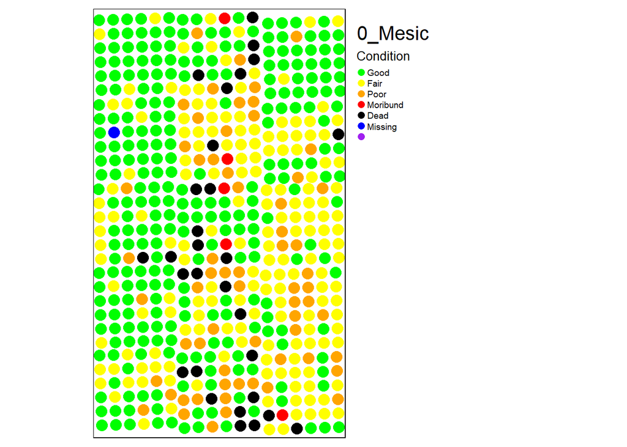

### 11_Frost

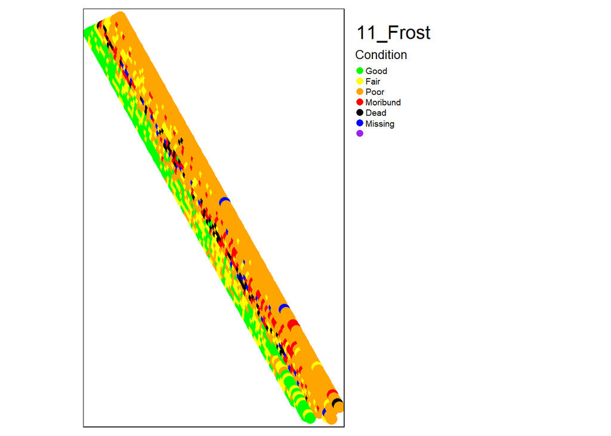

### 15_Mesic

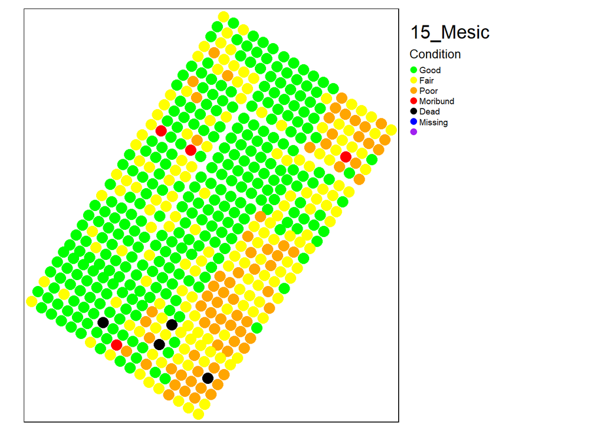

### 2_Mesic

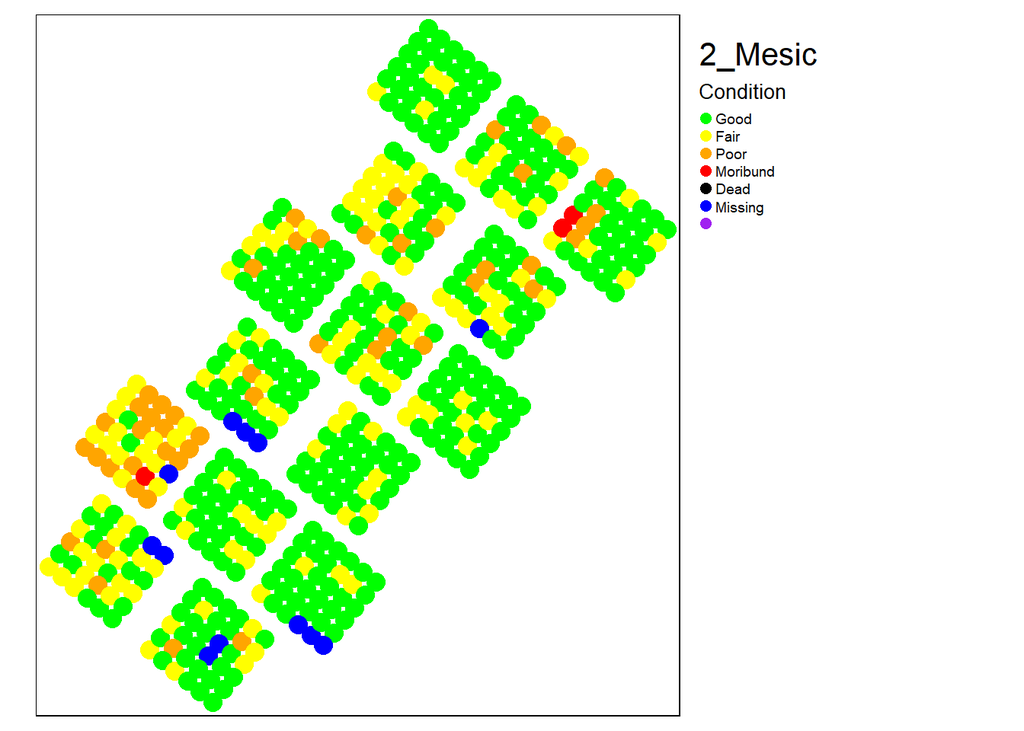

### 2_Wet

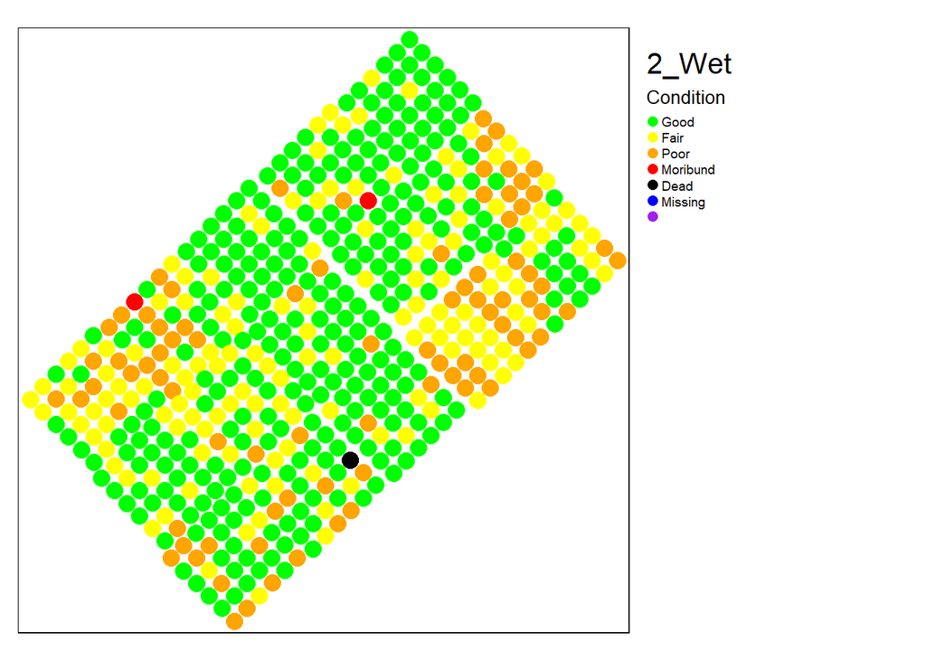

### 6_Mesic

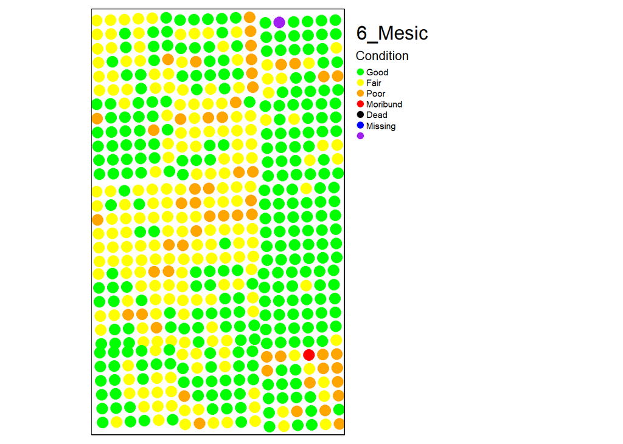

### 7_Mesic

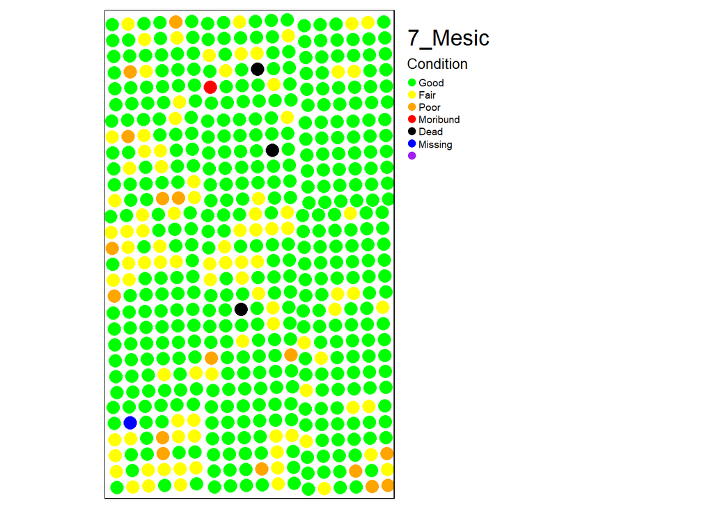

### 9_Demo

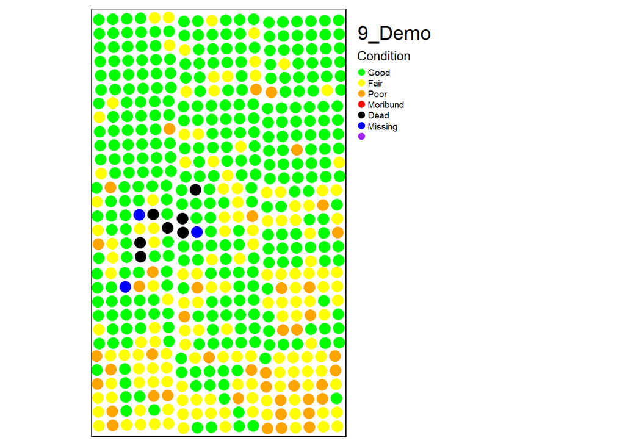

### 9_Dry

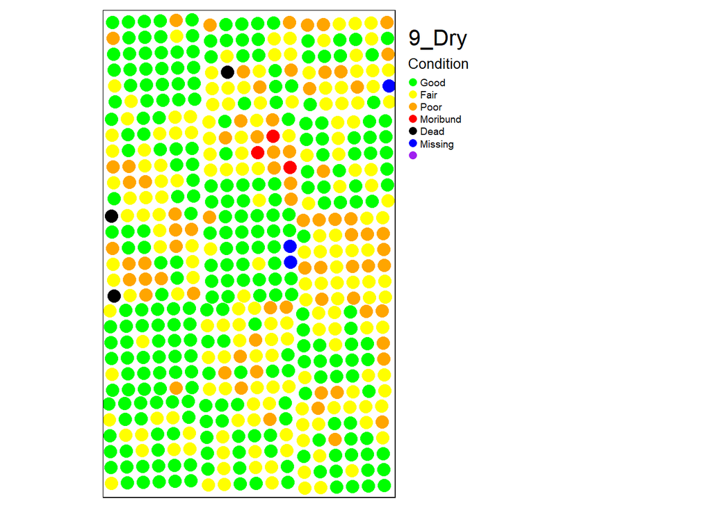

### 9_Mesic

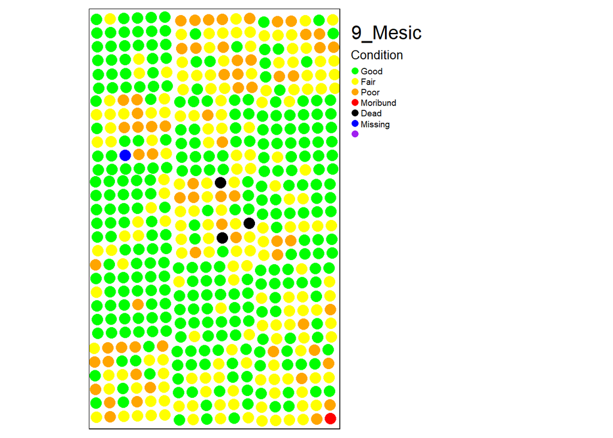